# R Colors

Austin Pesina

2021-08-21

# Introduction

The default color palettes used in computer graphics often leave much to to be desired. Besides being aesthetically vapid, they often have poor contrast and colors that are difficult to distinguish, especially for the color-blind.

Fortunately, cartographic researchers identified this problem quite some time ago. One of the results of this research was the ColorBrewer set of palettes. And lucky for us, these palettes are available to R programmers in the `rColorBrewer` package.

This demonstration script compares the default palette and a selected ColorBrewer palette.

# Data

Plot some data from a regression example given in Ott and Longneckers *Statistical Methods and Data Analysis*:

```r
FER.data <- read.table(header=TRUE, text="
additive    FER
0   1.30
0   1.35
0   1.44
0   1.52
0   1.56
0   1.61
0   1.48
0   1.56
0   1.45
0   1.14
20  2.17
20  2.11
20  2.08
20  2.13
20  2.22
20  2.29
20  2.33
20  2.24
20  2.16
20  2.21
40  2.30
40  2.34
40  2.20
40  2.38
40  2.48
40  2.44
40  2.37
40  2.43
40  2.37
40  2.41
60  2.47
60  2.51
60  2.79
60  2.40
60  2.55
60  2.67
60  2.50
60  2.55
60  2.60
60  2.49
80  3.31
80  3.17
80  3.24
80  3.21
80  3.35
80  3.38
80  3.42
80  3.36
80  3.25
80  3.51
100 4.92
100 3.87
100 4.81
100 4.88
100 5.06
100 5.09
100 4.97
100 4.95
100 4.59
100 4.76
")
```

# Exploratory Plot

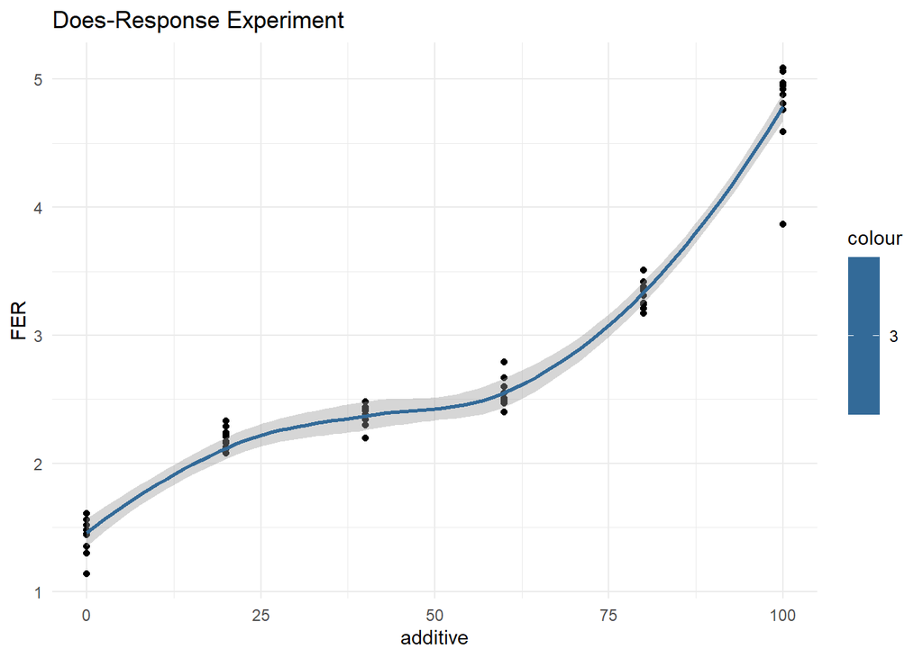

```r
ggplot(data=FER.data, aes(x=additive, y=FER)) +
  geom_point() +
  geom_smooth(method="loess", aes(color=3) ) +
  labs(title="Does-Response Experiment") +
  theme_minimal()
```

# Some Fitted Models

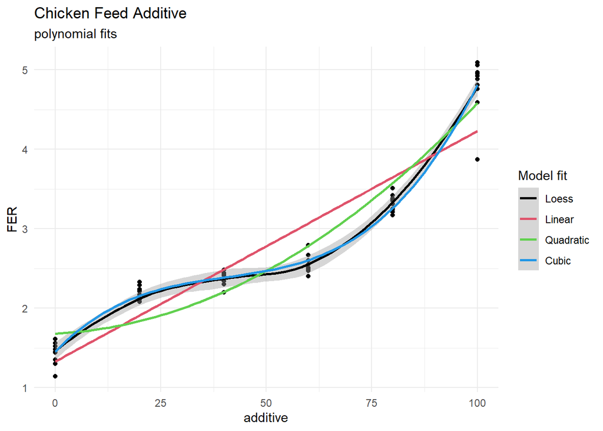

```r
ggplot(data=FER.data, aes(x=additive, y=FER)) +
  geom_point() +
  geom_smooth(method="loess", show.legend=TRUE, aes(color="1")) +
  geom_smooth(method="lm", formula='y~x', se=FALSE, show.legend=TRUE, aes(color="2") ) +
  geom_smooth(method="lm", formula='y~poly(x,2)', se=FALSE, show.legend=TRUE, aes(color="3") ) +
  geom_smooth(method="lm", formula='y~poly(x,3)', se=FALSE, show.legend=TRUE, aes(color="4") ) +
  scale_color_identity(name = "Model fit",
                          breaks = c("1", "2", "3", "4"),
                          labels = c("Loess", "Linear", "Quadratic", "Cubic"),
                          guide = "legend") +
  labs(title="Chicken Feed Additive", subtitle="polynomial fits") +
  theme_minimal()
```